# Case Study 1: EDA to Create a new Beer for U.S. Craft Enthusiasts

Domicia Herring & Taylor Bonar

2/28/2021

## Libraries & Package Setup

```r
# Load APIs
library(ggplot2)
library(dplyr)
library(maps)
library(mapproj)
library(stringr)
library(tidyr)
library(class)
library(caret)
library(e1071)
```

## Global Variable Setup & Cleanup

```r
# Importing input data
breweries = read.csv("Breweries.csv")
beers = read.csv("Beers.csv")

# Cleaning Data of invalid beginning space
breweries$State <- str_replace_all(breweries$State, "(\\s+)", "")
```

## Analysis

### How many breweries are present in each state?

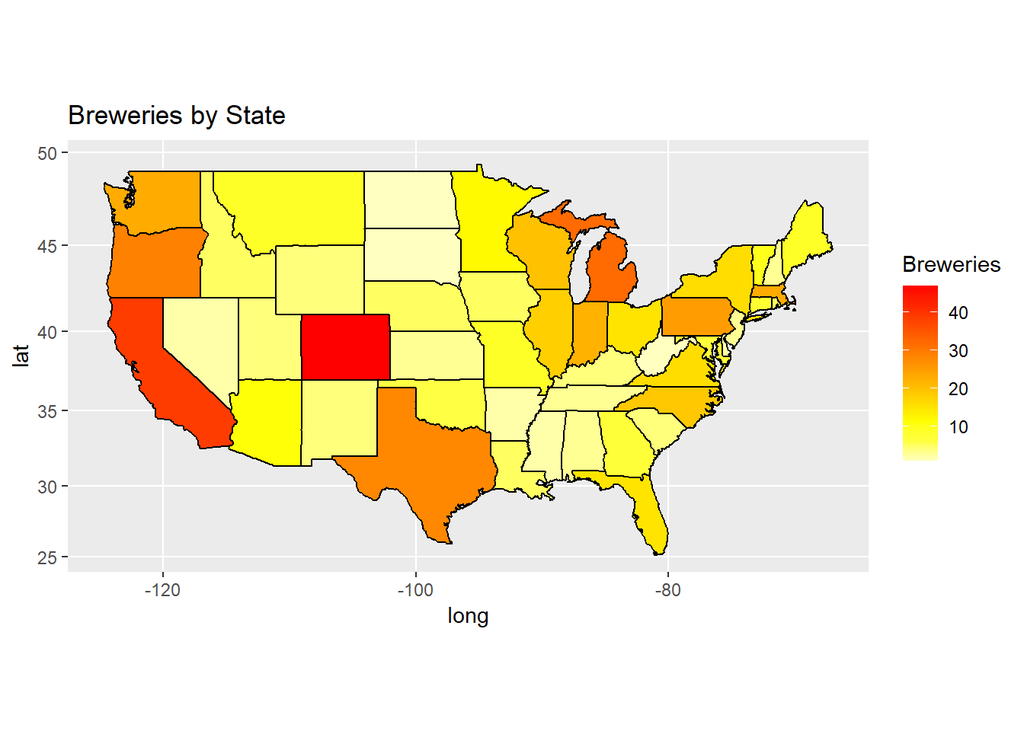

```r
# Data tidying
## Remove DC as its not a state but capitol
breweriesStates = filter(breweries,!grepl('DC', State))

# Data Transformation
## Create data frame with State name and abbreviation
stateLookup = data.frame(abb = state.abb, stateName = state.name)

## Merge stateLookup with breweriesMapData
breweriesStates2 = merge(breweriesStates,stateLookup,by.x="State",by.y="abb")

## count each occurrence of breweries in each state
breweriesMapData = count(breweriesStates2,stateName)
## remap columns for future merge of states and map
colnames(breweriesMapData) = c("region","Breweries")
breweriesMapData$region <- tolower(breweriesMapData$region)

## Create merge between states lat/long and breweries map data
states <- map_data("state")
map.df <- merge(states, breweriesMapData, by="region", all.x=T)
map.df <- map.df[order(map.df$order),]

## Create U.S. heat map to visualize states breweries count
ggplot(map.df, aes(x=long,y=lat,group=group))+
  geom_polygon(aes(fill=Breweries))+
  geom_path()+
  scale_fill_gradientn(colours=rev(heat.colors(10)),na.value="grey90")+ggtitle("Breweries by State")+coord_map()
```

### Merge beer data with the breweries data. Print the first 6 observations and the last six observations to check the merged file.

```r
# Join beer and breweries by common brewery identifier
beerAndBreweries = merge(beers, breweries, by.x="Brewery_id", by.y="Brew_ID")

# Remap columns named "Name" to be more descriptive/ubiquitous
colnames(beerAndBreweries)[2] = "Beer_Name"
colnames(beerAndBreweries)[8] = "Brewery_Name"

# Show first six rows
head(beerAndBreweries)
```

```
##   Brewery_id     Beer_Name Beer_ID   ABV IBU
## 1          1  Get Together    2692 0.045  50
## 2          1 Maggie's Leap    2691 0.049  26
## 3          1    Wall's End    2690 0.048  19
## 4          1       Pumpion    2689 0.060  38
## 5          1    Stronghold    2688 0.060  25
## 6          1   Parapet ESB    2687 0.056  47
##                                 Style Ounces       Brewery_Name        City
## 1                        American IPA     16 NorthGate Brewing  Minneapolis
## 2                  Milk / Sweet Stout     16 NorthGate Brewing  Minneapolis
## 3                   English Brown Ale     16 NorthGate Brewing  Minneapolis
## 4                         Pumpkin Ale     16 NorthGate Brewing  Minneapolis
## 5                     American Porter     16 NorthGate Brewing  Minneapolis
## 6 Extra Special / Strong Bitter (ESB)     16 NorthGate Brewing  Minneapolis
##   State
## 1    MN
## 2    MN
## 3    MN
## 4    MN
## 5    MN
## 6    MN
```

```r
# Show last six rows
tail(beerAndBreweries)
```

```
##      Brewery_id                 Beer_Name Beer_ID   ABV IBU
## 2405        556             Pilsner Ukiah      98 0.055  NA
## 2406        557  Heinnieweisse Weissebier      52 0.049  NA
## 2407        557           Snapperhead IPA      51 0.068  NA
## 2408        557         Moo Thunder Stout      50 0.049  NA
## 2409        557         Porkslap Pale Ale      49 0.043  NA
## 2410        558 Urban Wilderness Pale Ale      30 0.049  NA
##                        Style Ounces                  Brewery_Name          City
## 2405         German Pilsener     12         Ukiah Brewing Company         Ukiah
## 2406              Hefeweizen     12       Butternuts Beer and Ale Garrattsville
## 2407            American IPA     12       Butternuts Beer and Ale Garrattsville
## 2408      Milk / Sweet Stout     12       Butternuts Beer and Ale Garrattsville
## 2409 American Pale Ale (APA)     12       Butternuts Beer and Ale Garrattsville
## 2410        English Pale Ale     12 Sleeping Lady Brewing Company     Anchorage
##      State
## 2405    CA
## 2406    NY
## 2407    NY
## 2408    NY
## 2409    NY
## 2410    AK
```

### For metrics and later data analysis, beers with missing IBUs and ABV were removed for the below reasons.

#### International bitterness units (IBUs) may not be included for all beers as some are not geared for their bitter flavors (e.g. lagers), but rather, IBU tends to be used as a quality control metric. IBUs tend not to be centered on marketing to impact a consumer’s experience, but are simply there to satisfy some curiosities.

#### Alcohol by Volume (ABV) are not always printed, or rather required, to be displayed on beers by federal regulations. Instead, states regulate the advertisment of alcohol contents after the a unanimous vote in the Rubin vs Coors Brewing Co. 154 U.S.476 (1995). This court case argued against a 1935 decision ban on listing alcohol content to prevent “brewing wars”.

```r
# Observe summary of data, only IBU and ABV contains NAs
summary(beerAndBreweries)
```

```
##    Brewery_id     Beer_Name            Beer_ID            ABV
##  Min.   :  1.0   Length:2410        Min.   :   1.0   Min.   :0.00100
##  1st Qu.: 94.0   Class :character   1st Qu.: 808.2   1st Qu.:0.05000
##  Median :206.0   Mode  :character   Median :1453.5   Median :0.05600
##  Mean   :232.7                      Mean   :1431.1   Mean   :0.05977
##  3rd Qu.:367.0                      3rd Qu.:2075.8   3rd Qu.:0.06700
##  Max.   :558.0                      Max.   :2692.0   Max.   :0.12800
##                                                      NA's   :62
##       IBU            Style               Ounces      Brewery_Name
##  Min.   :  4.00   Length:2410        Min.   : 8.40   Length:2410
##  1st Qu.: 21.00   Class :character   1st Qu.:12.00   Class :character
##  Median : 35.00   Mode  :character   Median :12.00   Mode  :character
##  Mean   : 42.71                      Mean   :13.59
##  3rd Qu.: 64.00                      3rd Qu.:16.00
##  Max.   :138.00                      Max.   :32.00
##  NA's   :1005
##      City              State
##  Length:2410        Length:2410
##  Class :character   Class :character
##  Mode  :character   Mode  :character
##
##
##
##
```

```r
# We'll drop beers from the merged data that do not contain a value (i.e. NA)
beerAndBreweries2 = beerAndBreweries %>% drop_na(IBU, ABV)

# Observe data contains no NA values
summary(beerAndBreweries2)
```

```
##    Brewery_id     Beer_Name            Beer_ID          ABV
##  Min.   :  1.0   Length:1405        Min.   :   1   Min.   :0.02700
##  1st Qu.: 95.0   Class :character   1st Qu.: 772   1st Qu.:0.05000
##  Median :198.0   Mode  :character   Median :1439   Median :0.05700
##  Mean   :224.2                      Mean   :1415   Mean   :0.05991
##  3rd Qu.:351.0                      3rd Qu.:2069   3rd Qu.:0.06800
##  Max.   :547.0                      Max.   :2692   Max.   :0.12500
##       IBU            Style               Ounces      Brewery_Name
##  Min.   :  4.00   Length:1405        Min.   : 8.40   Length:1405
##  1st Qu.: 21.00   Class :character   1st Qu.:12.00   Class :character
##  Median : 35.00   Mode  :character   Median :12.00   Mode  :character
##  Mean   : 42.71                      Mean   :13.51
##  3rd Qu.: 64.00                      3rd Qu.:16.00
##  Max.   :138.00                      Max.   :32.00
##      City              State
##  Length:1405        Length:1405
##  Class :character   Class :character
##  Mode  :character   Mode  :character
##
##
##
```

### Exploring the median alcohol content and international bitterness unit for each state.

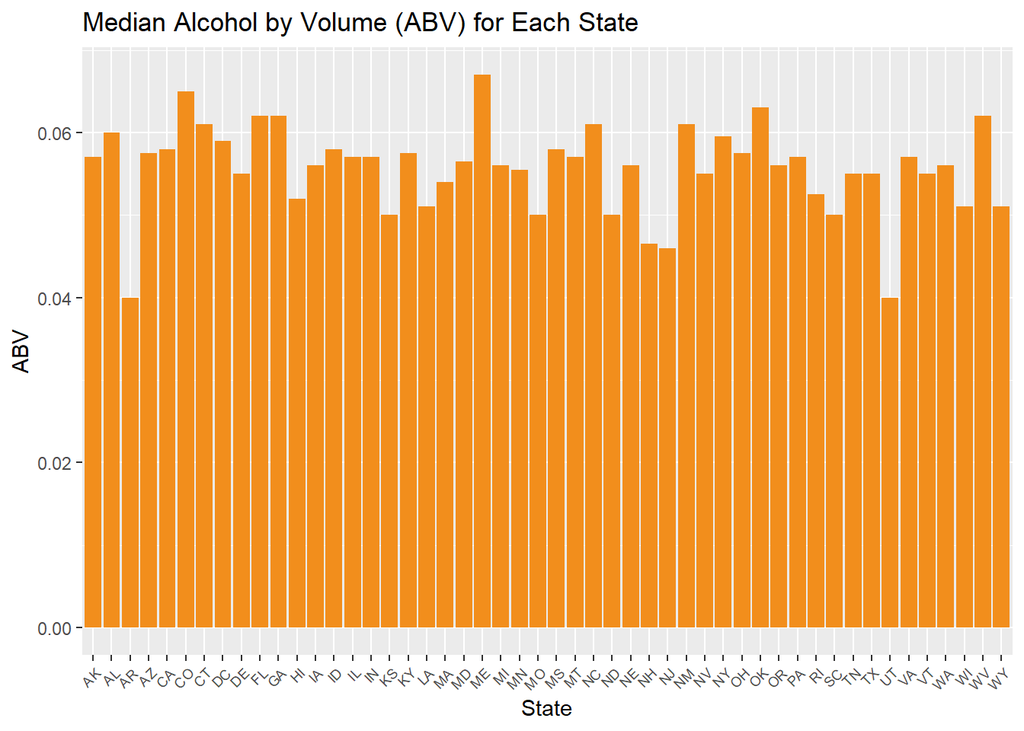

```r
# Calculate median of ABV or IBU by state grouping
medianABVbyState = aggregate(beerAndBreweries2$ABV,
          list(beerAndBreweries2$State),
          median)
medianIBUbyState = aggregate(beerAndBreweries2$IBU,
          list(beerAndBreweries2$State),
          median)

# Remap column names to be more descriptive
colnames(medianABVbyState) = c("State", "ABV")
colnames(medianIBUbyState) = c("State", "IBU")

# TODO: Add better visualization, too many states creates clutter and can overwhelm data visualization
ggplot(medianABVbyState, aes(x=State,y=ABV)) +
  geom_col(fill = "#f28e1c") +
  labs(title = "Median Alcohol by Volume (ABV) for Each State") +
  theme(axis.text.x = element_text(size = 7, angle = 45, hjust = 1))
```

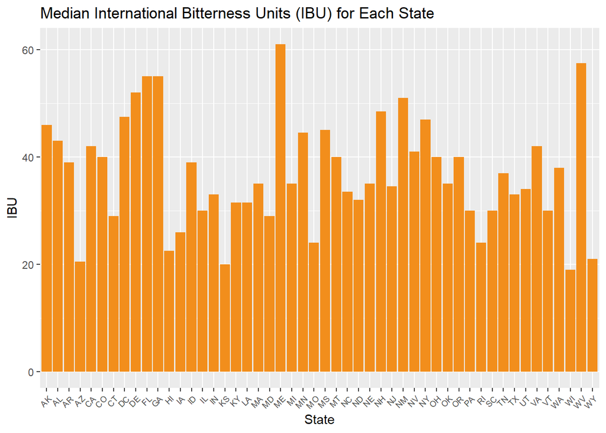

```r
ggplot(medianIBUbyState, aes(x=State,y=IBU)) +
  geom_col(fill = "#f28e1c") +
  labs(title = "Median International Bitterness Units (IBU) for Each State") +
  theme(axis.text.x = element_text(size = 7, angle = 45, hjust = 1))
```